# Homework

Ruizhi Li

2021-12-18

## HW0_2021_09_16

### Question

Use knitr to produce at least 3 examples(texts,figures,tables).  
Omitted here.

## HW1_2021_09_23

### 3.4

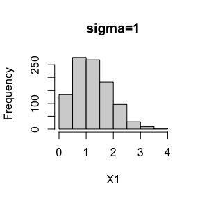

```r
set.seed(923)
rRayleigh = function(n, sigma=1) {
                      y = rexp(n, 1)
                      x = sigma*sqrt(2*y)
                      return(x)
                    }
         n = 1000
         X1 = rRayleigh(n,1)
         X3 = rRayleigh(n,3)
         X5 = rRayleigh(n,5)
         #compare mode via histogram
         hist(X1, main='sigma=1')
```

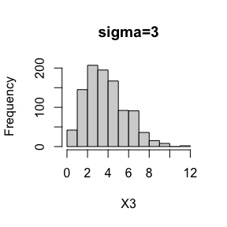

```r
         hist(X3, main='sigma=3')
```

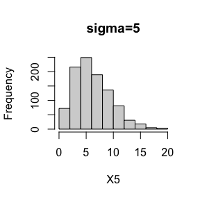

```r
         hist(X5, main='sigma=5')
```

Conclusion: It can be seen from the histogram verification that the generated sample mode is close to the theoretical mode $\sigma$.  
$\textbf{Method 2:}$  
Idea: Integrate the Rayleigh density from 0 to $x$ to get the Rayleigh distribution $F(x)=1-e^{-\frac{x^2}{2\sigma^2}}$, find the inverse of $F(x)$, that is, if $F(x)=u$, the solution is $x=\sqrt{log(\frac{1}{1-u})2\sigma^2}$

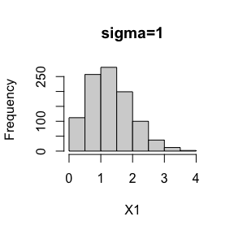

```r
set.seed(923)
rRayleigh2 = function(n, sigma=1) {
                      u<-runif(n)
                      x<-sqrt(log(1/u)*2*sigma^2)
                      return(x)
                    }
         n = 1000
         X1 = rRayleigh2(n,1)
         X3 = rRayleigh2(n,3)
         X5 = rRayleigh2(n,5)
         #compare mode via histogram
         hist(X1, main='sigma=1')
```

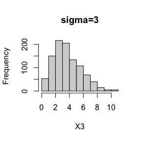

```r
         hist(X3, main='sigma=3')
```

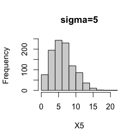

```r
         hist(X5, main='sigma=5')
```

Conclusion: It can be seen from the histogram verification that the generated sample mode is close to the theoretical mode $\sigma$.

### 3.11

Generate a random sample of size 1000 from a normal location mixture. The components of the mixture have $N (0, 1)$ and $N (3, 1)$ distributions with mixing probabilities $p_1$ and $p_2$ = 1 − $p_1$. Graph the histogram of the sample with density superimposed, for $p_1$ = 0.75. Repeat with different values for $p_1$ and observe whether the empirical distribution of the mixture appears to be bimodal. Make a conjecture about the values of $p_1$ that produce bimodal mixtures.  
$\textbf{Answer:}$  
Produce a mixed normal distribution:

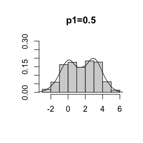

```r
set.seed(923)
n = 1000
p1 = 0.5
x1 = rnorm(n,0,1)
x2 = rnorm(n,3,1)
u = runif(n)
k = as.integer( u < p1 )
x = k*x1 + (1-k)*x2
hist( x, prob=T, ylab='', main='p1=0.5', xlab='', ylim=c(0,.3) )
lines( density(x) )
```

Conclusion: When $p_1=0.5$, the empirical distribution of the mixed variable produced is bimodal.  
Next, change $p_1$ and repeat different values of $p_1$ to infer the value of $p_1$ that can generate a bimodal mixing variable.

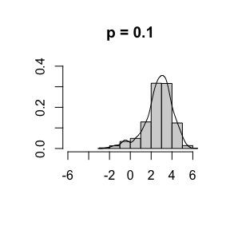

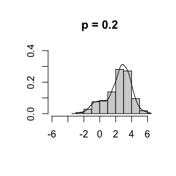

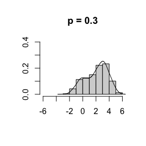

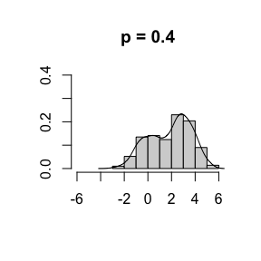

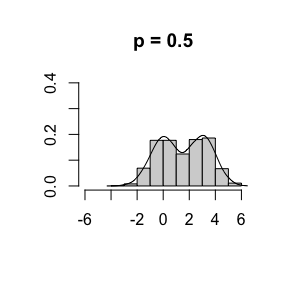

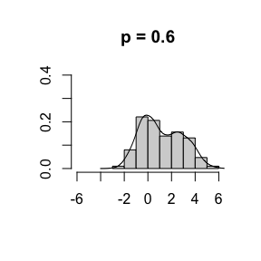

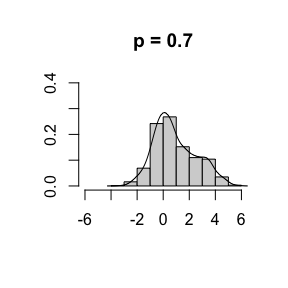

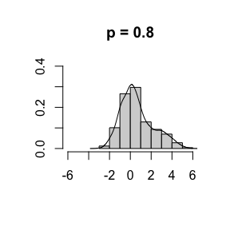

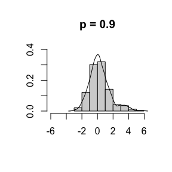

```r
for (p1 in seq(.1,.9,.1) ){
  x1 = rnorm(n,0,1)
  x2 = rnorm(n,3,1)
  u = runif(n)
  k = as.integer( u < p1 )
  x = k*x1 + (1-k)*x2
  hist( x, prob=T, ylab='', xlab='', xlim=c(-6,6),ylim=c(0,.4),main=paste('p =',p1) )
  lines( density(x) )
}
```

Conclusion: It can be seen from the figure that when $p_1$ is between $(0.4,0.6)$, the bimodal characteristic of the empirical distribution of mixed variables is obvious.

### 3.20

A compound Poisson process is a stochastic process $\{X(t),t\ge0\}$ that can be represented as the random sum $X(t)=\sum\limits_{i=1}^{N(t )}Y_i,t\ge0$, where$\{N(t),t\ge0\}$is a Poisson process and $Y_1,Y_2,\dots$ are iid and independent of $\{N(t), t\ge0\}$. Write a program to simulate a compound Poisson($\lambda$)–Gamma process ($Y$ has a Gamma distribution). Estimate the mean and the variance of $X(10)$ for several choices of the parameters and compare with the theoretical values.  
Hint: Show that $E[X(t)] = \lambda tE[Y_1]$ and $Var(X(t)) = \lambda tE[Y_1^2].$  
$\textbf{Answer:}$  
Ideas:  
1. First refer to the algorithm of the homogeneous Poisson process on the simulation interval $[0,t_0]$.  
(1) Let $S_1=0$;  
(2) For $j=1,2,\dots$, if $S_j\le t_0$  
(2)‘Generate $T_j$ following the distribution of $Exp(\lambda)$  
(2)’’ Let $S_j=T_1+\dots+T_j$  
(3)$N(t_0)=min_j(S_j>t_0)-1$

```r
rP_G = function(n,lambda,t0,r,beta) {
                      pp<-numeric(n)
                      ppgg<-numeric(n)
                      for(i in 1:n){
                         Tn<-rexp(100,lambda)
                         Sn<-cumsum(Tn)
                         nt0<-min(which(Sn>t0))-1
                         pp[i]<-nt0
                      }
                      for(j in 1:n){
                        ppgg[j]=sum(rgamma(pp[j],r,beta))
                      }
                      return(ppgg)
                    }
```

```r
set.seed(923)
x<-rP_G(n=2000,lambda=2,t0=10,r=1,beta=2)
mean(x)
```

```
## [1] 9.98977
```

```r
var(x)
```

```
## [1] 10.45287
```

After calculation, the theoretical mean value should be 2*10*1/2=10, and the theoretical variance should be 2*10*(1/4+1/4)=10. The simulation result is very close to the theoretical value.

```r
set.seed(929)
x<-rP_G(n=2000,lambda=3,t0=10,r=2,beta=3)
mean(x)
```

```
## [1] 20.02588
```

```r
var(x)
```

```
## [1] 19.67932
```

After calculation, the theoretical mean should be 3*10*2/3=20, and the theoretical variance should be 3*10*(4/9+2/9)=20. The simulation result is very close to the theoretical value.

## HW2_2021_09_30

### 5.4

Write a function to compute a Monte Carlo estimate of the $Beta(3,3)$ cdf, and use the function to estimate $F(x)$ for $x = 0.1, 0.2,..., 0.9$. Compare the estimates with the values returned by the $\mathbf{pbeta}$ function in R.  
$\textbf{Answer:}$

```r
cdfBeta = function(x, alpha=3, beta=3, m=10000 ) {
if ( any(x < 0) ) return (0)
stopifnot( x < 1 )
t = runif( m, min=0, max=x )
h = (x-0) * (1/beta(alpha,beta)) * t^(alpha-1) * (1-t)^(beta-1)
cdf = mean( h )
return( min(1,cdf) )
}
set.seed(930)
for (i in 1:9) {
         print( c(i/10 ,cdfBeta(i/10,3,3,10000), pbeta(i/10,3,3)) )
                      }
```

```
## [1] 0.100000000 0.008642246 0.008560000
## [1] 0.20000000 0.05807914 0.05792000
## [1] 0.3000000 0.1643854 0.1630800
## [1] 0.4000000 0.3169919 0.3174400
## [1] 0.5000000 0.5068114 0.5000000
## [1] 0.6000000 0.6801713 0.6825600
## [1] 0.7000000 0.8328279 0.8369200
## [1] 0.8000000 0.9382037 0.9420800
## [1] 0.9000000 0.9837243 0.9914400
```

Conclusion: Observation shows that the approximate value of Monte Carlo estimation is consistent with the pbeta() function.

### 5.9

The Rayleigh density is
$$f(x)=\frac{x}{\sigma^2} e^{-x^2/(2\sigma^2)},\ x\ge0,\sigma>0.$$
Implement a function to generate samples from a Rayleigh($\sigma$) distribution,using antithetic variables. What is the percent reduction in variance of $\frac{X+X'}{2}$ compared with $\frac{X_1+ X_2}{2}$ for independent $X_1,X_2$?
$\textbf{Answer:}$

```r
set.seed(222)
rRayleigh = function(n, sigma, antithetic=T){
                      u<-runif(n)
                      if(!antithetic) v<-runif(n)
                      else
                        v<-1-u
                      x<-(sqrt(log(1/(1-u))*2*sigma^2) +sqrt(log(1/(1-v))*2*sigma^2))/2
                      x
}

sigma <- c(1,3,5,7,9)
var_redu <- numeric(length(sigma))
for(i in 1:length(sigma)){
  MC1 <- rRayleigh(sigma=sigma[i],n=2000,antithetic = FALSE)
  MC2 <- rRayleigh(sigma=sigma[i],n=2000,antithetic = TRUE)
  var_redu[i] <- (var(MC1)-var(MC2))/var(MC1)
}

result <- rbind(sigma,var_redu)
knitr::kable(round(result,3))
```

| sigma | 1.000 | 3.000 | 5.000 | 7.000 | 9.000 |
| --- | --- | --- | --- | --- | --- |
| var_redu | 0.954 | 0.949 | 0.951 | 0.951 | 0.955 |

Conclusion: By changing different $\sigma$, the variance reduction percentages are all around 95%.

### 5.13

Find two importance functions $f_1$ and $f_2$ that are supported on $(1,\infty)$ and are’close’ to
$$g(x)=\frac{x^2}{\sqrt{2\pi}}e^{-x^2/2},\ x>1.$$
Which of your two importance functions should produce the smaller variance in estimating
$$\int_{1}^\infty{\frac{x^2}{\sqrt{2\pi}}e^{-x^2/2} dx}$$
by importance sampling? Explain.
$\textbf{Answer:}$
Choose important functions, I choose
$$f_1(x)=1/x^2,\ x\ge1$$
$$f_2(x)=\frac{1}{\sqrt{2\pi}}e^{-\frac{(x-1.5)^2}{2}},\ -\infty<x<\infty$$
Among them, the $F(x)$ of $f_1(x)$ is $1-\frac{1}{x}$, and the inverse transformation method can be used to generate random variables. $f_2(x)$ is the probability density function of $N(1.5,1)$.

```r
m <- 10000
theta.hat <- var <- numeric(2)

g <- function(x){
  x^2*exp(-x^2/2)*(x>1)/(sqrt(2*pi))
}

# f1
u<-runif(m)
x<-1/(1-u)
g_f<-g(x)*x^2
theta.hat[1]<-mean(g_f)
var[1]<-var(g_f)

# f2
x <- rnorm(m,mean = 1.5)
g_f <- g(x)/dnorm(x,mean = 1.5)
theta.hat[2] <- mean(g_f)
var[2] <- var(g_f)

theta.hat
```

```
## [1] 0.3979138 0.4063761
```

```r
var
```

```
## [1] 0.09221867 0.09024007
```

Conclusion: It can be seen that the variance produced by the second important function (normal) is smaller.  
Attachment: original function/two important function diagrams (proportion)

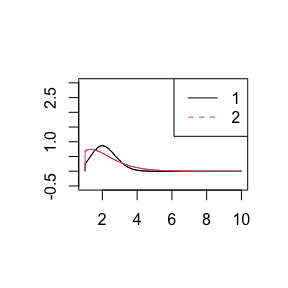

```r
y <- seq(1,10,.01)
plot(y,g(y)*y^2,col=1,lty=1,ylim=c(-0.5,3),"l",ylab="",xlab="")
lines(y,g(y)/dnorm(y,mean = 1.5),col=2,lty=1)
legend("topright",legend=c(1:2),lty=1:2,col=1:2)
```

### 5.14

Obtain a Monte Carlo estimate of
$$\int_{1}^\infty{\frac{x^2}{\sqrt{2\pi}}e^{-x^2/2} dx}$$
by importance sampling.
$\textbf{Answer:}$
From the previous question, it is better to take the normal important function.

```r
set.seed(1)
m <- 10000
theta.hat <- var <- numeric(1)
# f2
x <- rnorm(m,mean = 1.5)
g_f <- g(x)/dnorm(x,mean = 1.5)
theta.hat<- mean(g_f)

true <- integrate(g,1,upper = Inf)$value
c(theta.hat,true)
```

```
## [1] 0.399213 0.400626
```

## HW3_2021_10_14

### 6.5

Suppose a $95\%$ symmetric $t$-interval is applied to estimate a mean, but the sample data are non-normal. Then the probability that the confidence interval covers the mean is not necessarily equal to 0.95. Use a Monte Carlo experiment to estimate the coverage probability of the $t$-interval for random samples of $\chi^2(2)$ data with sample size n = 20. Compare your $t$-interval results with the simulation results in Example 6.4. ( The $t$-interval should be more robust to departures from normality than the interval for variance.)
$\textbf{Answer:}$
Idea: Use the $t$ interval to estimate the mean, that is, assume $t=t_{n-1} $, where $S =\sqrt{\frac{1}{n-1}\sum\limits_{i=1}^n(X_i-\bar{X})^2}$ is the sample standard deviation. The $95\%$ confidence interval of $\mu$ is
$$[\bar{X}-\frac{S}{\sqrt{n-1}}t_{0.975},\bar{X}-\frac{S}{\sqrt{n-1}}t_{ 0.025}].$$
The quantiles are all lower quantiles. Use Monte Carlo test to estimate the coverage rate of the $t$ interval for a random sample with a data size of 20 in $\chi^2(2)$:

```r
set.seed(222)
alpha = 0.05
n = 20
m = 10000

t_UCL = numeric(m)
t_LCL = numeric(m)
UCL<-numeric(m)

for(i in 1:m)
{
    x = rchisq(n, 2)
    t_LCL[i] = mean(x) - qt(1-alpha / 2, df=n-1, lower.tail = TRUE)*sd(x)/sqrt(n)
    t_UCL[i] = mean(x) - qt(alpha / 2, df=n-1, lower.tail = TRUE)*sd(x)/sqrt(n)
    UCL[i]<-(n-1)*var(x)/qchisq(alpha,df=n-1)
}

mean(t_LCL < 2 & t_UCL > 2)
```

```
## [1] 0.9177
```

```r
mean(UCL>4)
```

```
## [1] 0.7807
```

Conclusion: The simulation of the coverage rate of the t interval is only slightly lower than $95\%$, while the variance interval is much smaller. The result shows that the t interval is more stable than the variance interval.

### 6.A

Use Monte Carlo simulation to investigate whether the empirical Type I error rate of the $t$-test is approximately equal to the nominal significance level $\alpha$, when the sampled population is non-normal. The $t$-test is robust to mild departures from normality. Discuss the simulation results for the cases where the sampled population is (i) $\chi^2$(1), (ii) Uniform(0,2), and (iii) Exponential(rate=1 ). In each case, test $H_0:\mu = \mu_0$ vs $H_0:\mu\neq\mu_0$, where $\mu_0$ is the mean of $\chi^2(1)$, Uniform(0 ,2), and Exponential(1), respectively.  
$\textbf{Answer:}$  
Under the null hypothesis, $T^*=\frac{\bar{X}-\mu_0}{S/\sqrt{n}}\sim t_{n-1}$

```r
set.seed(222)
alpha = 0.05
n = 100
m = 10000

p_chi<-p_uni<-p_exp<-numeric(m)
for(i in 1:m){
  x_chi<-rchisq(n,df=1)
  x_uni<-runif(n,0,2)
  x_exp<-rexp(n,1)

  p_chi[i]=abs((mean(x_chi)-1)/sd(x_chi)*sqrt(n) )>=qt(0.975,n-1,lower.tail = TRUE)
  p_uni[i]=abs((mean(x_uni)-1)/sd(x_uni)*sqrt(n) )>=qt(0.975,n-1,lower.tail = TRUE)
  p_exp[i]=abs((mean(x_exp)-1)/sd(x_exp)*sqrt(n) )>=qt(0.975,n-1,lower.tail = TRUE)
}
mean(p_chi)
```

```
## [1] 0.0654
```

```r
mean(p_uni)
```

```
## [1] 0.0513
```

```r
mean(p_exp)
```

```
## [1] 0.0575
```

### Problem

If we obtain the powers for two methods under a particular simulation setting with 10,000 experiments: say, 0.651 for one method and 0.676 for another method. We want to know if the powers are different at 0.05 level.

#### (1)

What is the corresponding hypothesis test problem?  
Let the two tests be $T_1$ and $T_2$, the power of $T_i$ is defined as $p_i,i=1,2$, so the corresponding hypothesis test is: $H_0:p_1=p_2 ,\ H_1:p_1 \ neq p_2$.

#### (2)

What test should we use? Z-test, two-sample t-test, paired-t test or McNemar test? Why?
It can be regarded as two populations obeying the binomial distribution, testing the difference between the proportions with certain characteristics. Therefore, with a large sample, the expression of the available Z test statistic Z is as follows: $p=\frac{x_1+x_2}{n_1 +n_2}=\frac{p_1n_1+p_2n_2}{n_1+n_2}$, where p is the ratio of the two samples with this characteristic after the combination.
$$Z=\frac{p_1-p_2}{\sqrt{p(1-p)(\frac{1}{n_1}+\frac{1}{n_2})}}$$

#### (3)

Please provide the least necessary information for hypothesis testing.  
In addition to m=10000, it is better to know the sample size n used each time.

```r
res <- prop.test(x = c(6510, 6760), n = c(10000, 10000))
res
```

```
##
##  2-sample test for equality of proportions with continuity correction
##
## data:  c(6510, 6760) out of c(10000, 10000)
## X-squared = 13.885, df = 1, p-value = 0.0001944
## alternative hypothesis: two.sided
## 95 percent confidence interval:
##  -0.03819254 -0.01180746
## sample estimates:
## prop 1 prop 2
##  0.651  0.676
```

The p-value is less than 0.05, and the null hypothesis is rejected, and they are considered inconsistent.

## HW4_2021_10_21

### 6.C

Repeat Examples $6.8$ and $6.10$ for Mardia’s multivariate skewness test. Mardia $[187]$ proposed tests of multivariate normality based on multivariate generalizations of skewness and kurtosis. If $X$ and $Y$ are iid, the multivariate population skewness $\ beta_{1,d}$ is defined by Mardia as
$$\beta_{1, d}=E\left[(X-\mu)^{T} \Sigma^{-1}(Y-\mu)\right]^{3}$$
Under normality, $\beta_{1,d}=0$. The multivariate skewness statistic is
$$b_{1, d}=\frac{1}{n^{2}} \sum_{i, j=1}^{n}\left(\left(X_{i}-\bar{X} \right)^{T} \widehat{\Sigma}^{-1}\left(X_{j}-\bar{X}\right)\right)^{3}$$
where $\hat{\Sigma}$ is the maximum likelihood estimator of covariance. Large values of $b_{1,d}$ are significant. The asymptotic distribution of $nb_{1,d}/6$ is chisquared with $d(d + 1)(d + 2)/6$ degrees of freedom.

#### repeat example 6.8

Idea: For samples with sizes n=10,20,30,50,100 and 500, estimate the skewness normality test based on the asymptotic distribution of $b_{1, d}$ at the significance level $\alpha=0.05$ The first type of error rate. From the meaning of the title, the asymptotic distribution of the multivariate skewness statistics is
$$\frac{nb_{1,d}}{6}\stackrel{d}\longrightarrow \chi_{\frac{d(d+1)(d+2)}{6}}^2$$
Here d is the dimension of the random vector. Assume:
$$H_0:\beta_{1,d}=0\leftrightarrow H_1:\beta_{1,d}\neq0$$

```r
Mardia.sk<-function(x){
  n <- nrow(x)
  xbar <- apply(x, 2, mean)
  Sigma_hat <- (n-1)/n*cov(x)
  ni<-solve(Sigma_hat)
  sk<-numeric(1)
  for(i in 1:n)
    for(j in 1:n)
      sk <- sk + ((x[i,]-xbar)%*%ni%*%(x[j,]-xbar))^3
  return(sk/n^2)
}
```

Set similar to Example 6.8, p.reject[1:6] are the sample proportions for n=10,20,30,50,100,500 that are significant tests.

```r
library(MASS)
library(knitr)
n<-c(10,20,30,50,100,500)
d <- 2
cv <- 6/n*qchisq(0.05, d*(d+1)*(d+2)/6, lower.tail = F)
p.reject<-numeric(length(n))
m<-10000
set.seed(123)

for(i in 1:length(n)){
  Mardia.sktests<-numeric(m)
  for(j in 1:m){
    x <- mvrnorm(n[i], mu = rep(0,d), Sigma = diag(1,d))
    Mardia.sktests[j] <- as.integer(Mardia.sk(x)>= cv[i])
  }
  p.reject[i]<-mean(Mardia.sktests)
}
result <- rbind(n,p.reject)
rownames(result) <- c("n","estimate")
kable(result)
```

[output not shown]

#### repeat example 6.10

The pollution normal distribution is expressed as follows:
$$(1-\epsilon)N(0,I_d)+\epsilon N(0,100I_d),\quad 0\le\epsilon\le 1.$$
Imitate the 6.10 code:

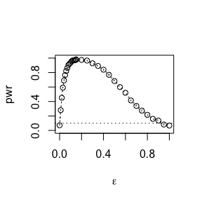

```r
library(MASS)
library(knitr)
alpha<-0.1
n<-30
m<-2500
d<-2
set.seed(123)
epsilon <- c(seq(0, .15, .01), seq(.15, 1, .05))
N <- length(epsilon)
pwr <- numeric(N)
cv <- 6/n*qchisq(alpha, d*(d+1)*(d+2)/6, lower.tail = F)
for (j in 1:N) {
  e <- epsilon[j]
  sktests <- numeric(m)
  for (i in 1:m) {
    index<- sample(c(1, 0), replace = TRUE,size = n, prob = c(1-e, e))
    x <- index*mvrnorm(n, rep(0,d), diag(1,d))+(1-index)*mvrnorm(n, rep(0,d), diag(100,d))
    sktests[i] <- as.integer(Mardia.sk(x) >= cv)
  }
  pwr[j] <- mean(sktests)
}
plot(epsilon, pwr, type = "b",xlab = bquote(epsilon), ylim = c(0,1))
abline(h = .1, lty = 3)
se <- sqrt(pwr * (1-pwr) / m)
lines(epsilon, pwr+se, lty = 3)
lines(epsilon, pwr-se, lty = 3)
```

The figure above shows the power curve. It reaches the highest when it is approximately 0.15, except for the two ends of $\epsilon$, the rest are all higher than 0.1. Some errors (such as 0 and 1 that do not strictly intersect with 0.1) may be due to the fact that n=30 is used here, and the sample is limited, but for convenience, the variance is not used as exact value as in Example 6.10.

## HW5_2021_10_28

### 7.7

Refer to Exercise $7.6$. Efron and Tibshirani discuss the following example $[84, Ch. 7]$. The five-dimensional scores data have a $5 × 5$ covariance matrix $\Sigma$, with positive eigenvalues $\lambda_1> \ dots >\lambda_5$. In principal components analysis,
$$\theta=\frac{\lambda_1}{\sum_{j=1}^5 \lambda_j}$$
measures the proportion of variance explained by the first principal component. Let $\hat{\lambda}_1> \dots >\hat{\lambda}_5$ be the eigenvalues of $\hat{\Sigma}$, where $\hat {\Sigma}$ is the $MLE$of $\Sigma$. Compute the sample estimate
$$\hat{\theta}=\frac{\hat{\lambda}_1}{\sum_{j=1}^5 \hat{\lambda}_j}$$
of $\theta$. Use bootstrap to estimate the bias and standard error of $\theta$.
$\textbf{Answer:}$

```r
library(bootstrap)
library(knitr)
```

```r
lambda_hat=eigen(cov(scor))$values
theta_hat=lambda_hat[1]/sum(lambda_hat)
theta_hat
```

```
## [1] 0.619115
```

```r
statis<-function(x,i){
  lambda.hat=eigen(cov(x[i,]))$values
  theta.hat=lambda.hat[1]/sum(lambda.hat)
  theta.hat
}

library(boot)
set.seed(222)
B<-2000
results<-boot(data=scor,statistic=statis,R=B)
results
```

```
##
## ORDINARY NONPARAMETRIC BOOTSTRAP
##
##
## Call:
## boot(data = scor, statistic = statis, R = B)
##
##
## Bootstrap Statistics :
##     original      bias    std. error
## t1* 0.619115 0.002691542  0.04741765
```

### 7.8

Refer to Exercise $7.7$. Obtain the jackknife estimates of bias and standard error of $\hat{\theta}$.  
$\textbf{Answer:}$

```r
thetai = function(x){
  lambda<-eigen(cov(x))$values
  lambda[1]/sum(lambda)
}
n =nrow(scor)
theta.jack = numeric(n)
x = as.matrix(scor)

for (i in 1:n) {
  theta.jack[i] = thetai(x[-i,])
}
theta.jack.bar = mean(theta.jack)
theta.jack.bar
```

```
## [1] 0.6191273
```

```r
bias.jack = (n-1)*( theta.jack.bar - theta_hat )
se.jack = sqrt( (n-1)*mean( (theta.jack-theta.jack.bar)^2 ) )
result <- cbind(theta_hat,theta.jack.bar,bias.jack,se.jack)
colnames(result) <- c("original","theta.jack.bar","bias","std.error")
kable(result)
```

| original | theta.jack.bar | bias | std.error |
| --- | --- | --- | --- |
| 0.619115 | 0.6191273 | 0.0010691 | 0.0495523 |

So $\hat{bias}_{jack}(\hat{\theta})=0.0010691,\ \hat{se}_{jack}(\hat{\theta})=0.0495523.$

### 7.9

Refer to Exercise $7.7$. Compute $95\%$ percentile and BCa confidence intervals for $\hat{\theta}$.  
$\textbf{Answer:}$

```r
boot.ci(results, type=c('perc','bca'))
```

```
## BOOTSTRAP CONFIDENCE INTERVAL CALCULATIONS
## Based on 2000 bootstrap replicates
##
## CALL :
## boot.ci(boot.out = results, type = c("perc", "bca"))
##
## Intervals :
## Level     Percentile            BCa
## 95%   ( 0.5239,  0.7085 )   ( 0.5165,  0.7034 )
## Calculations and Intervals on Original Scale
```

### 7.B

Repeat Project $7.A$ for the sample skewness statistic. Compare the coverage rates for normal populations (skewness $0$) and $\chi^2(5)$ distributions (positive skewness).  
$\textbf{Answer:}$

```r
sample.skewness = function (x,i) {
    mu = mean(x[i])
    n = length(x[i])
    a = 1/n * sum((x[i] - mu)^3)
    b = (1/n * sum((x[i] - mu)^2))^1.5
    return (a/b)
}
```

```r
theta=0
n<-100
m<-1e4
set.seed(222)
ci.norm<-ci.basic<-ci.perc<-matrix(0,m,2)
for(i in 1:m){
  xx<-rnorm(n,2,3)
  de<-boot(data=xx,statistic=sample.skewness,R=999)
  ci<-boot.ci(de,type=c("norm","basic","perc"))
  ci.norm[i,]<-ci$norm[2:3]
  ci.basic[i,]<-ci$basic[4:5]
  ci.perc[i,]<-ci$percent[4:5]
}
cat("norm:","coverage=",mean(ci.norm[,1]<=theta&ci.norm[,2]>=theta),"left.miss=",mean(ci.norm[,1]>theta),"right.miss",mean(ci.norm[,2]<theta),"\n",
    "basic:","coverage=",mean(ci.basic[,1]<=theta&ci.basic[,2]>=theta),"left.miss=",mean(ci.basic[,1]>theta),"right.miss",mean(ci.basic[,2]<theta),"\n",
    "perc:","coverage=",mean(ci.perc[,1]<=theta&ci.perc[,2]>=theta),"left.miss=",mean(ci.perc[,1]>theta),"right.miss",mean(ci.perc[,2]<theta)
    )
```

```
## norm: coverage= 0.9119 left.miss= 0.0444 right.miss 0.0437
##  basic: coverage= 0.9085 left.miss= 0.0462 right.miss 0.0453
##  perc: coverage= 0.9395 left.miss= 0.0311 right.miss 0.0294
```

```r
df=5
theta=sqrt(8/df)
n<-100
m<-1e4
set.seed(222)
ci.norm<-ci.basic<-ci.perc<-matrix(0,m,2)
for(i in 1:m){
  xx<-rchisq(n, df = df)
  de<-boot(data=xx,statistic=sample.skewness,R=999)
  ci<-boot.ci(de,type=c("norm","basic","perc"))
  ci.norm[i,]<-ci$norm[2:3]
  ci.basic[i,]<-ci$basic[4:5]
  ci.perc[i,]<-ci$percent[4:5]
}
cat("norm:","coverage=",mean(ci.norm[,1]<=theta&ci.norm[,2]>=theta),"left.miss=",mean(ci.norm[,1]>theta),"right.miss",mean(ci.norm[,2]<theta),"\n",
    "basic:","coverage=",mean(ci.basic[,1]<=theta&ci.basic[,2]>=theta),"left.miss=",mean(ci.basic[,1]>theta),"right.miss",mean(ci.basic[,2]<theta),"\n",
    "perc:","coverage=",mean(ci.perc[,1]<=theta&ci.perc[,2]>=theta),"left.miss=",mean(ci.perc[,1]>theta),"right.miss",mean(ci.perc[,2]<theta)
)
```

```
## norm: coverage= 0.7751 left.miss= 0.0252 right.miss 0.1997
##  basic: coverage= 0.7499 left.miss= 0.0472 right.miss 0.2029
##  perc: coverage= 0.7613 left.miss= 7e-04 right.miss 0.238
```

Conclusion: Observation shows that the confidence interval of the skewness of the normal population is estimated more accurately from the sample, the coverage rate is close to 0.95, and the Chi-square distribution is not accurate enough. At the same time, the left and right losses of the normal population are more symmetrical, while the chi-square distribution (with positive skewness) obviously has more losses on the right.

## HW6_2021_11_04

### 8.2

Implement the bivariate Spearman rank correlation test for independence $[255]$ as a permutation test. The Spearman rank correlation test statistic can be obtained from function cor with method = “spearman”. Compare the achieved significance level of the permutation test with the p -value reported by $\mathbf{cor.test}$ on the same samples.

```r
library(boot)
dCov<-function(x,y){
  x<-as.matrix(x)
  y<-as.matrix(y)
  n<-nrow(x)
  m<-nrow(y)
  if(n!=m||n<2)
    strp("Sample sizes must agree")
  if (!(all(is.finite(c(x, y)))))
    stop("Data contains missing or infinite values")
  Akl<-function(x){
    d<-as.matrix(dist(x))
    m1<-rowMeans(d)
    m2<-colMeans(d)
    M<-mean(d)
    a<-sweep(d,1,m1)
    b<-sweep(a,2,m2)
    b+M
  }
  A<-Akl(x)
  B<-Akl(y)
  sqrt(mean(A*B))
}
ndCov2<-function(z,ix,dims){
    p<-dims[1]
    q<-dims[2]
    d<-p+q
    x<-z[,1:p]
    y<-z[ix,-(1:p)]
    return(nrow(z)*dCov(x,y)^2)
}
```

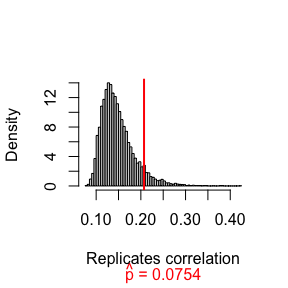

```r
data("iris")
z<-as.matrix(iris[1:50,1:4])
set.seed(12345)
boot.obj<-boot(data=z,statistic=ndCov2,R=9999,sim="permutation",dims=c(2,2))
tb<-c(boot.obj$t0,boot.obj$t)
p.cor<-mean(tb>=tb[1])
hist(tb,nclass="scott",main="",freq=F,xlab="Replicates correlation",sub=list(substitute(paste(hat(p), " = ",pvalue),list(pvalue = p.cor)),col="red"))
abline(v=boot.obj$t0,col="red",lwd=2)
```

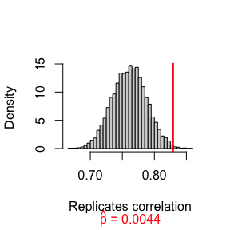

```r
ndCov22<-function(z,i,dims){
    p<-dims[1]
    q<-dims[2]
    d<-p+q
    x<-z[,1:p]
    y<-z[i,-(1:p)]
    return(cor.test(x,y,method="spearman",exact=F)$estimate)
}
  set.seed(12345)
  boot.obj<-boot(data=z,statistic=ndCov22,R=9999,sim="permutation",dims=c(2,2))
  tb<-c(boot.obj$t0,boot.obj$t)
  p.cor<-mean(tb>=tb[1])
  hist(tb,nclass="scott",main="",freq=F,xlab="Replicates correlation",sub=list(substitute(paste(hat(p), " = ",pvalue),list(pvalue = p.cor)),col="red"))
  abline(v=boot.obj$t0,col="red",lwd=2)
```

### Question

Design experiments for evaluating the performance of the NN, energy, and ball methods in various situations.  
(a) Unequal variances and equal expectations  
(b) Unequal variances and unequal expectations  
(c)Non-normal distributions: t distribution with 1 df (heavy-tailed distribution), bimodel distribution (mixture of two normal distributions)  
(d)Unbalanced samples (say, 1 case versus 10 controls)  
(e)Note: The parameters should be chosen such that the powers are distinguishable (say, range from 0.3 to 0.8).  
textbf{Answer:}

```r
library(RANN)
library(boot)
library(energy)
library(Ball)

Tn<-function(z,ix,sizes,k){
  n1 <- sizes[1]; n2 <- sizes[2]; n <- n1 + n2
  if(is.vector(z)) z <- data.frame(z);
  z <- z[ix, ];
  NN <- nn2(data=z, k=k+1)
  block1 <- NN$nn.idx[1:n1,-1]
  block2 <- NN$nn.idx[(n1+1):n,-1]
  i1 <- sum(block1 < n1); i2 <- sum(block2 > n1)
  (i1 + i2) / (k * n)
}
```

```r
#(a)
set.seed(123)
m<-200
nx<-30
p.values<-matrix(NA,m,3)
colnames(p.values)<-c("NN","energy","ball")
for(i in 1:m){
x<-rnorm(nx,0,1)
y<-rnorm(nx,0,2)
z<-c(x,y)
N<-c(nx,nx)
boot.obj <- boot(data=z,statistic=Tn,R=999,sim = "permutation", sizes = N,k=3)
ts <- c(boot.obj$t0,boot.obj$t)
p.values[i,1] <- mean(ts>=ts[1])
p.values[i,2]<-eqdist.etest(z,sizes=N,R=999)$p.value
p.values[i,3]<-bd.test(x=x,y=y,num.permutations=999,seed=i*12345)$p.value
}
power<-numeric(3)
power<-colMeans(p.values<0.1)
power
```

[output not shown]

```r
#(b)
set.seed(123)
m<-200
nx<-30
p.values<-matrix(NA,m,3)
colnames(p.values)<-c("NN","energy","ball")
for(i in 1:m){
x<-rnorm(nx,0,1)
y<-rnorm(nx,1,2)
z<-c(x,y)
N<-c(nx,nx)
boot.obj <- boot(data=z,statistic=Tn,R=999,sim = "permutation", sizes = N,k=3)
ts <- c(boot.obj$t0,boot.obj$t)
p.values[i,1] <- mean(ts>=ts[1])
p.values[i,2]<-eqdist.etest(z,sizes=N,R=999)$p.value
p.values[i,3]<-bd.test(x=x,y=y,num.permutations=999,seed=i*12345)$p.value
}
power<-numeric(3)
power<-colMeans(p.values<0.1)
power
```

[output not shown]

```r
#(c)
set.seed(123)
m<-200
nx<-30
p.values<-matrix(NA,m,3)
colnames(p.values)<-c("NN","energy","ball")
for(i in 1:m){
x<-rt(nx,df=1)
index<-sample(c(1,0),size=nx,replace=T,prob=c(0.5,0.5))
y<-index*rnorm(nx,0,1)+(1-index)*rnorm(nx,1,2)
z<-c(x,y)
N<-c(nx,nx)
boot.obj <- boot(data=z,statistic=Tn,R=999,sim = "permutation", sizes = N,k=3)
ts <- c(boot.obj$t0,boot.obj$t)
p.values[i,1] <- mean(ts>=ts[1])
p.values[i,2]<-eqdist.etest(z,sizes=N,R=999)$p.value
p.values[i,3]<-bd.test(x=x,y=y,num.permutations=999,seed=i*12345)$p.value
}
power<-numeric(3)
power<-colMeans(p.values<0.1)
power
```

[output not shown]

```r
#(d)
set.seed(123)
m<-200
p.values<-matrix(NA,m,3)
colnames(p.values)<-c("NN","energy","ball")
for(i in 1:m){
x<-rnorm(5,0,1)
y<-rnorm(50,0,1)
z<-c(x,y)
N<-c(length(x),length(y))
boot.obj <- boot(data=z,statistic=Tn,R=999,sim = "permutation", sizes = N,k=3)
ts <- c(boot.obj$t0,boot.obj$t)
p.values[i,1] <- mean(ts>=ts[1])
p.values[i,2]<-eqdist.etest(z,sizes=N,R=999)$p.value
p.values[i,3]<-bd.test(x=x,y=y,num.permutations=999,seed=i*12345)$p.value
}
power<-numeric(3)
power<-colMeans(p.values<0.1)
power
```

[output not shown]

## HW7_2021_11_11

### 9.3

Use the Metropolis-Hastings sampler to generate random variables from a standard Cauchy distribution. Discard the first $1000$ of the chain, and compare the deciles of the generated observations with the deciles of the standard Cauchy distribution (see qcauchy or qt with df=1 ). Recall that a Cauchy$(\theta,\eta)$ distribution has density function
$$f(x)=\frac{1}{\theta\pi(1+[(x-\eta)/\theta]^2)},\ -\infty<x<\infty,\theta>0 .$$
The standard Cauchy has the Cauchy$( \theta = 1, \eta = 0)$ density. (Note that the standard Cauchy density is equal to the Student t density with one degree of freedom.)
It is suggested that a choice of the distribution $g(\cdot|X_t)$ may be $N(\mu_t=X_t,\sigma^2).$
The following function is used to calculate the density of Cauchy$(\theta,\eta)$:

```r
f<-function(x,eta=0,theta=1){
  stopifnot(theta>0)
  return(1/(pi*theta*(1+((x-eta)/theta)^2)))
}
```

To imitate Example 9.1, use the normal suggestion distribution to generate Cauchy samples in the following simulation process

```r
cauchy.chain<-function(f=f,m,sigma,b,x0){
x<-numeric(m)
k<-0
x[1]<-x0
u<-runif(m)
for(i in 2:m){
  xt<-x[i-1]
  y<-rnorm(1,xt,sigma)
  num<-f(y)*dnorm(xt,y,sigma)
  den<-f(xt)*dnorm(y,xt,sigma)
  if(u[i]<=num/den) x[i]<-y
  else{
    x[i]<-xt
    k<-k+1
  }
}
index<-(b+1):m
y1<-x[index]
return(y1)
}
```

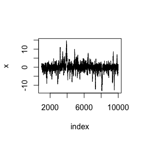

```r
set.seed(222)
m<-10000
sigma<-1
mu0<-0
b<-1000
x00<-rnorm(1,mu0,sigma)
y1<-cauchy.chain(f=f,m=m,sigma=sigma,b=b,x0=x00)
index<-(b+1):m
plot(index,y1,type="l",main="",ylab="x")
```

```r
q<-seq(0.1,0.9,0.1)
qxt<-quantile(y1,q)
qcc<-qcauchy(q)
result<-rbind(qxt,qcc)
knitr::kable(round(result,3))
```

|  | 10% | 20% | 30% | 40% | 50% | 60% | 70% | 80% | 90% |
| --- | --- | --- | --- | --- | --- | --- | --- | --- | --- |
| qxt | -2.307 | -1.199 | -0.659 | -0.300 | 0.017 | 0.307 | 0.667 | 1.166 | 2.143 |
| qcc | -3.078 | -1.376 | -0.727 | -0.325 | 0.000 | 0.325 | 0.727 | 1.376 | 3.078 |

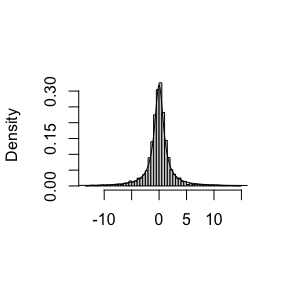

```r
a<-ppoints(100)
QC<-qcauchy(a)
Q<-quantile(y1,a)
hist(y1,breaks="scott",main="",xlab="",freq=F)
lines(QC,f(QC))
```

### 9.8

This example appears in $[40]$. Consider the bivariate density
$$f(x,y) \propto \binom{n}{x}y^{x+a-1}(1-y)^{n-x+b-1},\ x=0,1, \dots,n,0\le y \le 1.$$
It can be shown (see eg $[23]$) that for fixed $a, b, n$, the conditional distribu- tions are Binomial$(n, y)$ and Beta$(x + a, n − x + b)$. Use the Gibbs sampler to generate a chain with target joint density $f(x,y)$.

Imitation example 9.7

```r
B.B.chain<-function(a,b,n,N,burn){
  X<-matrix(0,N,2)
  y<-(0.5*n + a)/(n+a+b)
  X[1,]<-c(floor( n*y ),y)
for(i in 2:N){
  x2<-X[i-1,2]
  X[i,1]<-rbinom(1,n,y)
  x1<-X[i,1]
  X[i,2]<-rbeta(1,x1+a,n-x1+b)
}
  b<-burn+1
  x<-X[b:N,]
  return(x)
}
```

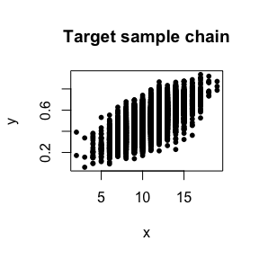

```r
set.seed(123)
N<-10000
burn<-1000
a<-2
b<-2
n<-22
x<-B.B.chain(a=a,b=b,n=n,N=N,burn=burn)
plot(x,xlab="x",ylab="y",main="Target sample chain",pch=16,cex=0.8)
```

### Question

For each of the above exercise, use the Gelman-Rubin method to monitor convergence of the chain, and run the chain until it converges approximately to the target distribution according to$\hat{R}< 1.2.$

#### ex9.3

Imitation example 9.8:

```r
Gelman.Rubin <- function(psi) {
# psi[i,j] is the statistic psi(X[i,1:j])
# for chain in i-th row of X
psi <- as.matrix(psi)
n <- ncol(psi)
k <- nrow(psi)

psi.means <- rowMeans(psi)
B <- n * var(psi.means)
psi.w <- apply(psi, 1, "var")
W <- mean(psi.w)
v.hat <- W*(n-1)/n + (B/n)
r.hat <- v.hat / W
return(r.hat)
}

##ex9.3
##generate the chains
set.seed(123)
n<-15000
b<-1000
k<-4
X<-matrix(0,nrow=k,ncol=n)
for(i in 1:k)
  X[i,]<-cauchy.chain(f=f,m=n,sigma=sigma,b=0,x0=8)


#compute diagnostic statistics
psi <- t(apply(X, 1, cumsum))
for (i in 1:nrow(psi))
psi[i,] <- psi[i,] / (1:ncol(psi))
print(Gelman.Rubin(psi))
```

```
## [1] 1.025496
```

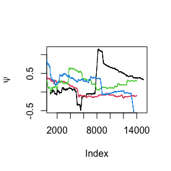

```r
for (i in 1:k)
      if(i==1){
        plot((b+1):n,psi[i, (b+1):n], type="l",
            xlab='Index', ylab=bquote(psi))
      }else{
        lines(psi[i, (b+1):n], col=i)
    }
```

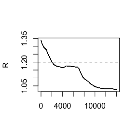

```r
rhat <- rep(0, n)
for (j in (b+1):n)
rhat[j] <- Gelman.Rubin(psi[,1:j])
plot(rhat[(b+1):n], type="l", xlab="", ylab="R")
abline(h=1.2, lty=2)
```

#### ex9.8

```r
##ex9.8
##generate the chains
set.seed(123)
b<-1000
k<-4 #number of chains
N<-15000
X<-matrix(0,nrow=k,ncol=N)
a<-2
b1<-2
n<-22
for(i in 1:k)
  X[i,]<-B.B.chain(a=a,b=b1,n=n,N=N,burn=0)[,2] #此处y全序列


#compute diagnostic statistics
psi <- t(apply(X, 1, cumsum))
for (i in 1:nrow(psi))
psi[i,] <- psi[i,] / (1:ncol(psi))
print(Gelman.Rubin(psi))
```

```
## [1] 1.008829
```

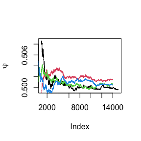

```r
#plot psi for the four chains par(mfrow=c(2,2))
for (i in 1:k)
      if(i==1){
        plot((b+1):N,psi[i, (b+1):N], type="l",
            xlab='Index', ylab=bquote(psi))
      }else{
        lines(psi[i, (b+1):N], col=i)
    }
```

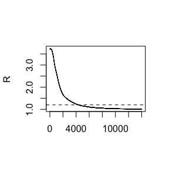

```r
    par(mfrow=c(1,1)) #restore default

#plot the sequence of R-hat statistics
rhat <- rep(0, N)
for (j in (b+1):N)
rhat[j] <- Gelman.Rubin(psi[,1:j])
plot(rhat[(b+1):N], type="l", xlab="", ylab="R")
abline(h=1.2, lty=2)
```

```r
##ex9.8
##generate the chains
set.seed(123)
b<-1000
k<-4 #number of chains
N<-15000
X<-matrix(0,nrow=k,ncol=N)
a<-2
b1<-2
n<-22
for(i in 1:k)
  X[i,]<-B.B.chain(a=a,b=b1,n=n,N=N,burn=0)[,1]

#compute diagnostic statistics
psi <- t(apply(X, 1, cumsum))
for (i in 1:nrow(psi))
psi[i,] <- psi[i,] / (1:ncol(psi))
print(Gelman.Rubin(psi))
```

```
## [1] 1.158608
```

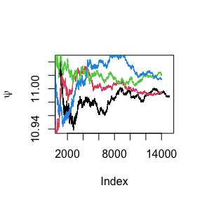

```r
for (i in 1:k)
      if(i==1){
        plot((b+1):N,psi[i, (b+1):N], type="l",
            xlab='Index', ylab=bquote(psi))
      }else{
        lines(psi[i, (b+1):N], col=i)
      }
```

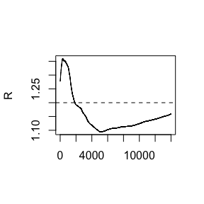

```r
#plot the sequence of R-hat statistics
rhat <- rep(0, N)
for (j in (b+1):N)
rhat[j] <- Gelman.Rubin(psi[,1:j])
plot(rhat[(b+1):N], type="l", xlab="", ylab="R")
abline(h=1.2, lty=2)
```

## HW8_2021_11_18

### 11.3

(a)Write a function to compute the $k^{th}$ term in
$$\sum\limits_{k=0}^\infty \frac{(-1)^k}{k!2^k} \frac{||a||^{2k+2}}{(2k+ 1)(2k+2)} \frac{\Gamma(\frac{d+1}{2})\Gamma(k+\frac{3}{2})}{\Gamma(k+\frac{d}{ 2}+1)},$$
where $d \ge 1$ is an integer, a is a vector in $R^d$, and $||\cdot||$ denotes the Euclidean norm. Perform the arithmetic so that the coefficients can be computed for (almost) arbitrarily large $k$ and $d$. (This sum converges for all $a \in R^d$).
(b) Modify the function so that it computes and returns the sum.
(c)Evaluate the sum when $a=(1,2)^T.$
(a)

```r
compute_kth<-function(k,a,d=length(a)){
  a.norm2<-sum(abs(a)^2)
  y0<-a.norm2
  if(k==0) return(y0/2*exp(lgamma((d+1)/2)+lgamma(1.5)-lgamma(d/2+1)))
  y<-rep(0,k)
  y[1]<--1/2*a.norm2^2
  if(k>1) for(i in 2:k){
    y[i]<--y[i-1]/(2*i)*a.norm2
  }
  return(y[k]/(2*k+1)/(2*k+2)*exp(lgamma((d+1)/2)+lgamma(k+1.5)-lgamma(d/2+k+1)))
}
```

```r
compute_sum<-function(k,a,d=length(a)){
  a.norm2<-sum(abs(a)^2)
  y<-rep(0,k)
  kth<-rep(0,k)
  y0<-a.norm2
  y[1]<--1/2*a.norm2^2
  kth[1]<-y[1]/3/4*exp(lgamma((d+1)/2)+lgamma(2.5)-lgamma(d/2+2))
  for(i in 2:k){
    y[i]<--y[i-1]/(2*i)*a.norm2
    kth[i]<-y[i]/(2*i+1)/(2*i+2)*exp(lgamma((d+1)/2)+lgamma(i+1.5)-lgamma(d/2+i+1))
  }
  y0/2*exp(lgamma((d+1)/2)+lgamma(1.5)-lgamma(d/2+1))+sum(kth)
}
```

```r
a<-c(1,2)
compute_sum(k=100,a=a)
```

```
## [1] 1.532164
```

```r
compute_sum(k=200,a=a)
```

```
## [1] 1.532164
```

```r
compute_sum(k=300,a=a)
```

```
## [1] 1.532164
```

### 11.5

Write a function to solve the equation
$$\frac{2\Gamma(\frac{k}{2})}{\sqrt{\pi(k-1)}\Gamma(\frac{k-1}{2})}\int_0^{ c_{k-1}} (1+\frac{u^2}{k-1})^{-k/2}du = \frac{2\Gamma(\frac{k+1}{2}) }{\sqrt{\pi k}\Gamma(\frac{k}{2})}\int_0^{c_k} (1+\frac{u^2}{k})^{-(k+1) /2}du$$
for $a$, where
$$c_k=\sqrt{\frac{a^2 k}{k+1-a^2}}.$$
Compare the solutions with the points $A(k)$ in Exercise 11.4.

```r
k = c( 4:25,100,500,1000 )
object = function( a, df ){
  a2 = a^2
  arg = sqrt( a2*df/(df + 1 - a2) )
  Sk = pt( q=arg, df=df, lower=F)
  arg = sqrt( a2*(df-1)/(df - a2) )
  Sk_1 = pt( q=arg, df=df-1, lower=F)
  return( Sk-Sk_1 )
}
for ( i in 1:length(k) )  {
    print( c( k[i], uniroot(object, lower=1,upper=2, df=k[i])$root ) )
                                 }
```

```
## [1] 4.000000 1.492103
## [1] 5.000000 1.533556
## [1] 6.000000 1.562744
## [1] 7.00000 1.58443
## [1] 8.000000 1.601185
## [1] 9.000000 1.614521
## [1] 10.00000  1.62539
## [1] 11.000000  1.634419
## [1] 12.000000  1.642038
## [1] 13.000000  1.648554
## [1] 14.00000  1.65419
## [1] 15.000000  1.659114
## [1] 16.000000  1.663452
## [1] 17.000000  1.667303
## [1] 18.000000  1.670745
## [1] 19.00000  1.67384
## [1] 20.000000  1.676637
## [1] 21.000000  1.679178
## [1] 22.000000  1.681496
## [1] 23.00000  1.68362
## [1] 24.000000  1.685572
## [1] 25.000000  1.687373
## [1] 100.000000   1.720608
## [1] 500.000000   1.729755
## [1] 1000.000000    1.730907
```

```r
#11.5
solve_equation<-function(k){
   f=function(y,kk){
     (1+y^2/(kk-1))^(-kk/2)
     }
   object=function(a,kx){
     2*exp(lgamma(kx/2)-lgamma(kx/2-0.5))/sqrt(pi*(kx-1))*integrate(f,lower=0,upper=sqrt(a^2*(kx-1)/(kx-a^2)),kk=kx)$value-2*exp(lgamma(kx/2+0.5)-lgamma(kx/2))/sqrt(pi*kx)*integrate(f,lower=0,upper=sqrt(a^2*(kx)/(kx+1-a^2)),kk=kx+1)$value
     }
   uniroot(object, lower=1,upper=2,kx=k)$root
}

k = c( 4:25,100,500,1000 )
for ( i in 1:length(k) )
    print( c( k[i], solve_equation(k[i]) ))
```

```
## [1] 4.000000 1.492103
## [1] 5.000000 1.533556
## [1] 6.000000 1.562744
## [1] 7.00000 1.58443
## [1] 8.000000 1.601185
## [1] 9.000000 1.614521
## [1] 10.00000  1.62539
## [1] 11.000000  1.634419
## [1] 12.000000  1.642038
## [1] 13.000000  1.648554
## [1] 14.00000  1.65419
## [1] 15.000000  1.659114
## [1] 16.000000  1.663452
## [1] 17.000000  1.667303
## [1] 18.000000  1.670745
## [1] 19.00000  1.67384
## [1] 20.000000  1.676637
## [1] 21.000000  1.679178
## [1] 22.000000  1.681496
## [1] 23.00000  1.68362
## [1] 24.000000  1.685572
## [1] 25.000000  1.687373
## [1] 100.000000   1.720608
## [1] 500.000000   1.729755
## [1] 1000.000000    1.730907
```

Conclusion: Same result as 11.4.

### Question

Suppose $T_1,\cdots,T_n$ are iid samples drawn from the exponential distribution with expectation $\lambda$. Those values greater than $\tau$ are not observed due to right censorship, so that the observed values are $Y_i = T_iI (T_i ≤ \tau) + \tau I(T_i> \tau),i = 1,\cdots,n.$ Suppose $\tau$ = 1 and the observed $Y_i$ values are as follows:
$$0.54, 0.48, 0.33, 0.43, 1.00, 1.00, 0.91, 1.00, 0.21, 0.85$$
Use the E-M algorithm to estimate $\lambda$, compare your result with the observed data MLE (note: $Y_i$ follows a mixture distribution).
Observed data: $Y_1,\dots,Y_n$, Compelete data: $T_1,\dots,T_n$;
$$L(\lambda|T_1,\cdots,T_n)=\lambda^n e^{-\lambda(t_1+\dots+t_n)}$$
$$l(\lambda|T_1,\cdots,T_n)=nln\lambda-\lambda(t_1+\dots+t_n)$$
E-step:
$$E_{\hat{\lambda}_{(i)}}[logL(\lambda;T_1,\dots,T_n)|Y_1,\dots,Y_n]=nln\lambda-\lambda \cdot \sum\ limits_{i:T_i=Y_i\le \tau}t_i-\lambda\cdot E_1 \cdot E(T|T>\tau,\hat{\lambda}_{(i)})$$
Where $E_1$ is $T_i>\tau$, that is, the number of $Y_i=\tau$.
$E(T|T>\tau,\hat{\lambda}_{(i)})= \frac{\int_\tau^\infty t\hat{\lambda}_{(i)} e^{ -\hat{\lambda}_{(i)} t} dt}{\int_\tau^\infty \hat{\lambda}_{(i)} e^{-\hat{\lambda}_{( i)} t}dt}=\frac{1}{\hat{\lambda}_{(i)}}+\tau$
$$\hat{\lambda}_{(i+1)}=\frac{n}{\sum\limits_{i:T_i=Y_i\le \tau}t_i+E_1(\frac{1}{\hat {\lambda}_{(i)}}+\tau)}$$
Substitute data:
$$\hat{\lambda}_{(i+1)}=\frac{10}{3.75+3*(\frac{1}{\hat{\lambda}_{(i)}}+1) }$$

```r
em<-function(lambda,max.it=10000,eps=1e-6){
  i<-1
  lambda1<-lambda
  lambda2<-10/(3.75+3*(1/lambda1+1))
  while(abs(lambda1-lambda2)>=eps){
    lambda1<-lambda2
    lambda2<-10/(3.75+3*(1/lambda1+1))
    if(i==max.it) break
    i<-i+1
  }
  return(lambda2)
}
em(lambda=0.9)
```

```
## [1] 1.037037
```

```r
em(lambda=1.1)
```

```
## [1] 1.037037
```

In addition, if the MLE method is used
$$L(\lambda|Y_1,\cdots,Y_n)=\lambda^{E_0} e^{-\lambda \sum\limits_{i:Y_i\le \tau}y_i}*(e^{-\lambda \tau})^{E_1}$$
$$MLE:\hat{\lambda}=\frac{E_0}{\sum\limits_{i:Y_i\le \tau}y_i+\tau E_1}=\frac{7}{3.75+3}=1.037037037.$$
Of course, in the original question, the expectation is $\lambda$, so the actual distribution is $Exp(1/\lambda)$, and the above results need to be taken as the reciprocal, namely $1/1.037037037=0.9642857143.$
Therefore, the results of the EM algorithm and the MLE method are very consistent here.

## HW9_2021_11_25

### ex1(Page 204)

Why are the following two invocations of lapply() equivalent?

```r
trims <- c(0, 0.1, 0.2, 0.5)
x <- rcauchy(100)
lapply(trims, function(trim) mean(x, trim = trim))
```

```
## [[1]]
## [1] -1.823399
##
## [[2]]
## [1] -0.1903784
##
## [[3]]
## [1] -0.1192673
##
## [[4]]
## [1] -0.2010135
```

```r
lapply(trims, mean, x = x)
```

```
## [[1]]
## [1] -1.823399
##
## [[2]]
## [1] -0.1903784
##
## [[3]]
## [1] -0.1192673
##
## [[4]]
## [1] -0.2010135
```

In the first invocation, each value of trims is used as the value of the “trim” parameter in the mean function. The result is the mean value of x when 4 trims are taken respectively.  
In the second invocation, first the first parameter x of mean(), this is provided by the third parameter “x=x” of lapply() (name corresponding), and then the position is matched, the first parameter of lapply() Parameter, assigned to the second parameter of the calling function mean.  
From the above analysis, the actual purpose of the two sentences is the same, so the result is the same.

### ex5(Page 204)

For each model in the previous two exercises, extract $R^2$ using the function below.

```r
rsq <- function(mod) summary(mod)$r.squared
```

ex3:

```r
formulas <- list(
  mpg ~ disp,
  mpg ~ I(1 / disp),
  mpg ~ disp + wt,
  mpg ~ I(1 / disp) + wt
)
result.ex3.lapply <- lapply(formulas, function(x) lm(formula = x, data = mtcars))
sapply(result.ex3.lapply, rsq)
```

```
## [1] 0.7183433 0.8596865 0.7809306 0.8838038
```

```r
result.ex3.loops <- vector("list", length(formulas))
for (i in seq_along(formulas)){
  result.ex3.loops[[i]] <- lm(formulas[[i]], data = mtcars)
}
sapply(result.ex3.loops, rsq)
```

```
## [1] 0.7183433 0.8596865 0.7809306 0.8838038
```

ex4:

```r
bootstraps <- lapply(1:10, function(i) { rows <- sample(1:nrow(mtcars), rep = TRUE)
mtcars[rows, ]
})
result.ex4.lapply <- lapply(bootstraps, lm, formula = mpg ~ disp)
sapply(result.ex4.lapply, rsq)
```

```
##  [1] 0.7557647 0.7602159 0.7609264 0.7568812 0.8037517 0.7450611 0.7106901
##  [8] 0.7165113 0.5901888 0.7817205
```

```r
result.ex4.loops <- vector("list", length(bootstraps))
for (i in seq_along(bootstraps)){
  result.ex4.loops[[i]] <- lm(mpg ~ disp, data = bootstraps[[i]])
}
sapply(result.ex4.loops, rsq)
```

```
##  [1] 0.7557647 0.7602159 0.7609264 0.7568812 0.8037517 0.7450611 0.7106901
##  [8] 0.7165113 0.5901888 0.7817205
```

The results of using loops and lapply are the same.

### ex1(Page 214)

Use vapply() to:  
a) Compute the standard deviation of every column in a nu- meric data frame.  
b) Compute the standard deviation of every numeric column in a mixed data frame. (Hint: you’ll need to use vapply() twice.)

```r
vapply(cars, sd, numeric(1))
```

```
##     speed      dist
##  5.287644 25.769377
```

```r
vapply(iris[vapply(iris, is.numeric, logical(1))],sd, numeric(1))
```

```
## Sepal.Length  Sepal.Width Petal.Length  Petal.Width
##    0.8280661    0.4358663    1.7652982    0.7622377
```

### ex7(Page 214)

Implement mcsapply(), a multicore version of sapply(). Can you implement mcvapply(), a parallel version of vapply()? Why or why not?

```r
library(parallel)

mcsapply<-function(x,Fun){
  cl<-makeCluster(detectCores())
  results<-parSapply(cl,x,Fun)
  stopCluster(cl)
  return(results)
}

boot_lm <- function(i) {
  boot_df <- function(x) x[sample(nrow(x), rep = T), ]
  rsquared <- function(mod) summary(mod)$r.square
  rsquared(lm(mpg ~ wt + disp, data = boot_df(mtcars)))
  }

n<-1e4
system.time(sapply(1:n,boot_lm))
```

```
##  用户  系统  流逝
## 8.840 0.036 8.989
```

```r
system.time(mcsapply(1:n,boot_lm))
```

```
##  用户  系统  流逝
## 0.014 0.009 4.039
```

vapply() does not map to lapply() like sapply(), so it will be more difficult.